# Psychophysiological Effects of a Gong Music Intervention: A Pre-Post Analysis with an Controlled Trial

Frederico Pedrosa

2025-05-14

# 1 **Preparing libraries and environment**

```r
#-------------------------------------------------------------------------------
knitr::opts_chunk$set(echo = TRUE, warning = FALSE, message = FALSE,
                      fig.width = 8, fig.height = 6, fig.align = "center")

# Packages
library(readxl)
library(dplyr)
library(MASS)
library(tidyr)
library(stringr)     # For string manipulation (useful for renaming)
library(gtsummary)   # For descriptive and regression tables
library(geepack)
library(emmeans)     # For post-hoc of GEEs
library(effectsize)  # For effect sizes
library(rstatix)     # For additional tests if necessary
library(kableExtra)  # For tables (if not using gtsummary for everything)
library(knitr)
library(ggplot2)     # For graphics (optional, but recommended)
library(WebPower)    # For power analysis
library(conflicted)
library(corrplot)    # For visualization
library(correlation) # For a more complete approach with p-values (optional)
library(olsrr)
library(lm.beta)
library(car)
conflict_prefer("select", "dplyr")
conflict_prefer("filter", "dplyr") # Good practice if using MASS too
```

## 1.1 Introduction and initial data processing

```r
data_original <- read_excel("~/PedroOP/dados_Pedro.xlsx")
df <- as.data.frame(data_original) # Remove 3rd row, convert to data.frame


# Step 1: Ensure the ID column exists
if ("Código" %in% names(df)) {
  if (!"ID" %in% names(df)) {
    df <- df %>% dplyr::rename(ID = `Código`) # Specify dplyr::rename
    cat("Column 'Código' renamed to 'ID'.\n")
  } else {
    cat("Column 'ID' already exists. Column 'Código' also present, but not renamed over 'ID'.\n")
  }
} else if (!"ID" %in% names(df)) {
  warning("Columns 'ID' or 'Código' not found. Creating 'ID' from row number.")
  df <- df %>% dplyr::mutate(ID = row_number()) # Specify dplyr::mutate
} else {
  cat("Column 'ID' already present in the loaded dataframe.\n")
}
```

```
## Column 'Código' renamed to 'ID'.
```

```r
# Convert key columns to factors
df <- df %>%
  dplyr::mutate( # Specify dplyr::mutate
    ID = factor(ID),
    Group = factor(Grupo, levels = c(1, 2), labels = c("Experimental", "Control")), # Renamed 'Grupo' to 'Group'
    Sex = case_when( # Renamed 'Sexo' to 'Sex'
      as.character(Sexo) %in% c("M", "Masculino", "1") ~ "Male",
      as.character(Sexo) %in% c("F", "Feminino", "2") ~ "Female",
      TRUE ~ NA_character_
    ),
    Sex = factor(Sex)
  )

# AND THE ORIGINAL NAMES MUST EXACTLY MATCH YOUR FILE
# This map defines how original (Portuguese) column names are mapped to shorter, English-based names.
column_map <- list(
  # Original T1 names from your df                           = # Short names
  "Av1 DASS-21Depressão"                                   = "DASS_Dep",
  "Av1 DASS-21Ansiedade"                                   = "DASS_Anx",
  "Av1 DASS-21Estresse"                                    = "DASS_Str",
  "Av 1 Reg. Emoc.Reavaliação Cognitiva"                   = "RegEmoc_ReavCog",  # Corrected space
  "Av 1 Reg. Emoc.Supressão Emocional"                     = "RegEmoc_SupEmoc",  # Corrected space
  "Av1 MAIA-BRPercebendo"                                  = "MAIA_Perceiving",
  "Av1 MAIA-BRSem distração"                                = "MAIA_NoDistraction",
  "Av1 MAIA-BRSem preocupação"                              = "MAIA_NoWorrying",
  "Av1 MAIA-BRRegulação Atencional"                         = "MAIA_AttnRegulation",
  "Av1 MAIA-BRConsciência Emocional"                        = "MAIA_EmoAwareness",
  "Av1 MAIA-BRAutorregulação"                               = "MAIA_SelfRegulation",
  "Av1 MAIA-BREscuta do corpo"                              = "MAIA_BodyListening",
  "Av1 MAIA-BRConfiando"                                   = "MAIA_Trusting",
  "Av1 ECOMCoping focado na emoção"                         = "ECOM_EmotionFocused",
  "Av1 ECOMCoping focado no problema"                       = "ECOM_ProblemFocused",
  "Av1 ECOMCoping focado na evitação/desligamento"          = "ECOM_Avoidance",
  "Avaliação 1_  PNS index:"                               = "HRV_PNS",    # Corrected: underscore and two spaces
  "Avaliação 1_  SNS index:"                               = "HRV_SNS",    # Corrected: underscore and two spaces
  "Avaliação 1_  Stress index:"                            = "HRV_Stress", # Corrected: underscore and two spaces
  "Avaliação 1_  Mean RR  (ms):"                           = "HRV_MeanRR", # Corrected: underscore, two spaces, and two spaces before (ms)
  "Avaliação 1_  SDNN (ms):"                               = "HRV_SDNN",   # Corrected: underscore and two spaces
  "Avaliação 1_  Mean HR (beats/min):"                     = "HRV_MeanHR", # Corrected: underscore and two spaces
  "Avaliação 1_  RMSSD (ms):"                              = "HRV_RMSSD",  # Corrected: underscore and two spaces
  "Avaliação 1_  pNNxx (%):"                               = "HRV_pNNxx",  # Corrected: underscore and two spaces
  "Avaliação 1_ LF/HF ratio:...74"                         = "HRV_LFHF",   # Corrected: underscore

  # Original T2 names from your df
  "Av2 DASS-21Depressão"                                   = "DASS_Dep",
  "Av2 DASS-21Ansiedade"                                   = "DASS_Anx",
  "Av2 DASS-21Estresse"                                    = "DASS_Str",
  "Av 2 Reg. Emoc.Reavaliação Cognitiva"                   = "RegEmoc_ReavCog",  # Corrected space
  "Av 2 Reg. Emoc.Supressão Emocional"                     = "RegEmoc_SupEmoc",  # Corrected space
  "Av2 MAIA-BRPercebendo"                                  = "MAIA_Perceiving",
  "Av2 MAIA-BRSem distração"                                = "MAIA_NoDistraction",
  "Av2 MAIA-BRSem preocupação"                              = "MAIA_NoWorrying",
  "Av2 MAIA-BRRegulação Atencional"                         = "MAIA_AttnRegulation",
  "Av2 MAIA-BRConsciência Emocional"                        = "MAIA_EmoAwareness",
  "Av2 MAIA-BRAutorregulação"                               = "MAIA_SelfRegulation",
  "Av2 MAIA-BREscuta do corpo"                              = "MAIA_BodyListening",
  "Av2 MAIA-BRConfiando"                                   = "MAIA_Trusting",
  "Av2 ECOMCoping focado na emoção"                         = "ECOM_EmotionFocused",
  "Av2 ECOMCoping focado no problema"                       = "ECOM_ProblemFocused",
  "Av2 ECOMCoping focado na evitação/desligamento"          = "ECOM_Avoidance",
  "Avaliação 2_  PNS index:"                               = "HRV_PNS",    # Corrected: underscore and two spaces
  "Avaliação 2_  SNS index:"                               = "HRV_SNS",    # Corrected: underscore and two spaces
  "Avaliação 2_  Stress index:"                            = "HRV_Stress", # Corrected: underscore and two spaces
  "Avaliação 2_  Mean RR  (ms):"                           = "HRV_MeanRR", # Corrected: underscore, two spaces, and two spaces before (ms)
  "Avaliação 2_  SDNN (ms):"                               = "HRV_SDNN",   # Corrected: underscore and two spaces
  "Avaliação 2_  Mean HR (beats/min):"                     = "HRV_MeanHR", # Corrected: underscore and two spaces
  "Avaliação 2_  RMSSD (ms):"                              = "HRV_RMSSD",  # Corrected: underscore and two spaces
  "Avaliação 2_  pNNxx (%):"                               = "HRV_pNNxx",  # Corrected: underscore and two spaces
  "Avaliação 2_ LF/HF ratio:...129"                        = "HRV_LFHF"    # Corrected: underscore
)

# Rename columns in the main dataframe 'df'
# Rename columns in the main dataframe 'df'
for (original_name in names(column_map)) {
  short_name_base <- column_map[[original_name]]
  time_suffix <- ""

  # Corrected conditions to identify T1 and T2 based on column_map keys
  if (startsWith(original_name, "Av1") || startsWith(original_name, "Av 1 ") || startsWith(original_name, "Avaliação 1_")) {
    time_suffix <- "_T1"
  } else if (startsWith(original_name, "Av2") || startsWith(original_name, "Av 2 ") || startsWith(original_name, "Avaliação 2_")) {
    time_suffix <- "_T2"
  }

  if (original_name %in% names(df)) {
    new_col_name <- if (nchar(time_suffix) > 0) paste0(short_name_base, time_suffix) else short_name_base

    # Check if new_col_name would create a duplicate with an *existing different original column*
    # This is a more advanced check, often not needed if map is well-designed
    # but good for complex scenarios.
    # For now, the direct assignment is usually okay if the map logic is sound.
    names(df)[names(df) == original_name] <- new_col_name
  } else {
    warning(paste("Original column from map not found for renaming:", original_name))
  }
}

# Unique short outcome names (base for .value in pivot_longer and for labels)
unique_short_outcome_names <- unique(unname(unlist(column_map)))

# Convert to numeric after renaming
cols_to_numeric <- names(df)[str_detect(names(df), "_T[12]$")]
df <- df %>% dplyr::mutate(across(all_of(cols_to_numeric), as.numeric))

# Create long dataset
df_long <- df %>%
  pivot_longer(
    cols = matches("_T[12]$"), # Use matches for more robust selection of T1/T2 columns
    names_to = c(".value", "Time"),
    # Updated pattern to capture the base name and the T1/T2 suffix
    names_pattern = paste0("^(", paste(unique_short_outcome_names, collapse = "|"), ")_(T[12])$"),
    values_drop_na = FALSE
  ) %>%
  dplyr::mutate(Time = factor(Time, levels = c("T1", "T2")))

# Verify
# head(df_long)
# names(df_long) # Should have ID, Group, Sex, Age, ... then unique_short_outcome_names and Time column
```

# 2 **Descriptive statistics and comparisons between groups at Time 1**

```r
demographic_base_vars <- c(
  "Idade", "Estatura (m)", "Massa Corporal (Kg) Avaliação 1", "IMC avaliação 1"
)


demographic_vars_original_names <- c("Idade", "Estatura (m)", "Massa Corporal (Kg) Avaliação 1", "IMC avaliação 1")
demographic_vars_english_names <- c("Age", "Height_m", "Weight_kg_T1", "BMI_T1") # Target names

for(i in seq_along(demographic_vars_original_names)){
    if(demographic_vars_original_names[i] %in% names(df)){
        df <- df %>% dplyr::rename(!!demographic_vars_english_names[i] := !!sym(demographic_vars_original_names[i]))
    }
}
demographic_base_vars_existing <- demographic_vars_english_names[demographic_vars_english_names %in% names(df)]


outcome_vars_t1_renamed <- names(df)[str_detect(names(df), paste0("^(", paste(unique_short_outcome_names, collapse="|"), ")_T1$"))]
outcome_vars_t1_renamed <- outcome_vars_t1_renamed[outcome_vars_t1_renamed %in% names(df)] # Ensure they exist

cols_to_keep_for_df_t1 <- c(
  "ID", "Group", "Sex",
  demographic_base_vars_existing,
  outcome_vars_t1_renamed
)
cols_to_keep_for_df_t1 <- unique(cols_to_keep_for_df_t1)
cols_to_keep_for_df_t1 <- cols_to_keep_for_df_t1[cols_to_keep_for_df_t1 %in% names(df)]


df_t1 <- df %>%
  dplyr::select(all_of(cols_to_keep_for_df_t1)) %>%
  dplyr::rename_with(~str_remove(., "_T1$"), .cols = all_of(outcome_vars_t1_renamed))


demographics_for_gtsummary <- demographic_base_vars_existing[demographic_base_vars_existing %in% names(df_t1)]
outcomes_for_gtsummary <- unique_short_outcome_names[unique_short_outcome_names %in% names(df_t1)]

vars_for_gtsummary_final <- c(
  demographics_for_gtsummary,
  outcomes_for_gtsummary
)
vars_for_gtsummary_final <- unique(vars_for_gtsummary_final)
vars_for_gtsummary_final <- vars_for_gtsummary_final[vars_for_gtsummary_final %in% names(df_t1)]

table1_desc_baseline <- df_t1 %>%
  dplyr::select(Group, Sex, all_of(vars_for_gtsummary_final)) %>%
  tbl_summary(
    by = Group,
    type = list( # Specify type for problematic variables if any, e.g.
      MAIA_NoDistraction ~ "continuous",
      ECOM_Avoidance ~ "continuous"
    ),
    label = list(
      Age ~ "Age (years)",
      Height_m ~ "Height (m)",
      Weight_kg_T1 ~ "Weight (kg, T1)",
      BMI_T1 ~ "BMI (kg/m², T1)",
      DASS_Dep ~ "DASS-21 Depression",
      DASS_Anx ~ "DASS-21 Anxiety",
      DASS_Str ~ "DASS-21 Stress",
      RegEmoc_ReavCog ~ "Emot. Reg. Cognitive Reappraisal",
      RegEmoc_SupEmoc ~ "Emot. Reg. Emotional Suppression",
      MAIA_Perceiving ~ "MAIA Perceiving",
      MAIA_NoDistraction ~ "MAIA Not Distracting",
      MAIA_NoWorrying ~ "MAIA Not Worrying",
      MAIA_AttnRegulation ~ "MAIA Attention Regulation",
      MAIA_EmoAwareness ~ "MAIA Emotional Awareness",
      MAIA_SelfRegulation ~ "MAIA Self-Regulation",
      MAIA_BodyListening ~ "MAIA Body Listening",
      MAIA_Trusting ~ "MAIA Trusting",
      ECOM_EmotionFocused ~ "ECOM Emotion-Focused Coping",
      ECOM_ProblemFocused ~ "ECOM Problem-Focused Coping",
      ECOM_Avoidance ~ "ECOM Avoidance Coping",
      HRV_PNS ~ "HRV PNS Index",
      HRV_SNS ~ "HRV SNS Index",
      HRV_Stress ~ "HRV Stress Index",
      HRV_MeanRR ~ "HRV Mean RR (ms)",
      HRV_SDNN ~ "HRV SDNN (ms)",
      HRV_MeanHR ~ "HRV Mean HR (bpm)",
      HRV_RMSSD ~ "HRV RMSSD (ms)",
      HRV_pNNxx ~ "HRV pNNxx (%)",
      HRV_LFHF ~ "HRV LF/HF Ratio"
    ),
    statistic = list(
      all_continuous() ~ "{mean} ({sd})",
      all_categorical() ~ "{n} ({p}%)"
    ),
    digits = all_continuous() ~ 2,
    missing_text = "(Missing)"
  ) %>%
  add_p(test = list(all_continuous() ~ "t.test", all_categorical() ~ "fisher.test"),
        pvalue_fun = ~style_pvalue(., digits = 3)) %>%
  add_overall() %>%
  modify_header(
    label = "**Characteristic (Time 1)**",
    p.value = "**p-value**",
    stat_0 = "**Total (N = {N})**"
  ) %>%
  modify_caption("**Table 1. Baseline Characteristics (Time 1) of Participants by Group**") %>%
  bold_labels()

table1_desc_baseline
```

**Table 1. Baseline Characteristics (Time 1) of Participants by Group**

| **Characteristic (Time 1)** | **Total (N = 22)**<sup>1</sup> | **Experimental** N = 11<sup>1</sup> | **Control** N = 11<sup>1</sup> | **p-value**<sup>2</sup> |
| --- | --- | --- | --- | --- |
| Sex |  |  |  | 0.090 |
| Female | 18 (82%) | 7 (64%) | 11 (100%) |  |
| Male | 4 (18%) | 4 (36%) | 0 (0%) |  |
| Age (years) | 25.59 (6.02) | 25.91 (6.20) | 25.27 (6.12) | 0.811 |
| Height (m) | 1.65 (0.09) | 1.67 (0.09) | 1.62 (0.07) | 0.161 |
| Weight (kg, T1) | 63.30 (11.31) | 66.43 (11.58) | 60.17 (10.62) | 0.202 |
| BMI (kg/m², T1) | 23.30 (3.35) | 23.74 (3.43) | 22.87 (3.38) | 0.555 |
| DASS-21 Depression | 14.73 (9.12) | 17.45 (8.20) | 12.00 (9.55) | 0.167 |
| DASS-21 Anxiety | 15.00 (11.11) | 12.91 (13.46) | 17.09 (8.26) | 0.392 |
| DASS-21 Stress | 20.09 (8.65) | 20.91 (10.01) | 19.27 (7.44) | 0.669 |
| Emot. Reg. Cognitive Reappraisal | 27.36 (7.58) | 25.82 (7.14) | 28.91 (8.02) | 0.351 |
| Emot. Reg. Emotional Suppression | 17.05 (5.96) | 17.45 (6.14) | 16.64 (6.05) | 0.756 |
| MAIA Perceiving | 3.50 (0.99) | 3.59 (1.00) | 3.41 (1.03) | 0.679 |
| MAIA Not Distracting | 1.95 (0.83) | 1.82 (0.86) | 2.09 (0.82) | 0.455 |
| MAIA Not Worrying | 1.74 (0.91) | 1.79 (0.92) | 1.70 (0.94) | 0.821 |
| MAIA Attention Regulation | 1.92 (0.74) | 2.03 (0.64) | 1.81 (0.84) | 0.496 |
| MAIA Emotional Awareness | 3.71 (0.99) | 3.67 (1.05) | 3.75 (0.98) | 0.868 |
| MAIA Self-Regulation | 2.10 (1.18) | 2.39 (1.03) | 1.82 (1.29) | 0.268 |
| MAIA Body Listening | 2.41 (1.13) | 2.88 (0.95) | 1.94 (1.13) | 0.048 |
| MAIA Trusting | 2.91 (1.48) | 3.18 (1.46) | 2.64 (1.52) | 0.402 |
| ECOM Emotion-Focused Coping | 19.91 (5.10) | 19.00 (5.48) | 20.82 (4.77) | 0.416 |
| ECOM Problem-Focused Coping | 10.68 (3.00) | 10.09 (3.05) | 11.27 (2.97) | 0.368 |
| ECOM Avoidance Coping | 6.55 (2.86) | 6.45 (3.08) | 6.64 (2.77) | 0.886 |
| HRV PNS Index | -0.35 (0.96) | -0.02 (1.23) | -0.68 (0.44) | 0.119 |
| HRV SNS Index | 0.63 (1.11) | 0.33 (1.41) | 0.93 (0.62) | 0.218 |
| HRV Stress Index | 10.72 (3.20) | 9.96 (3.63) | 11.49 (2.65) | 0.275 |
| HRV Mean RR (ms) | 838.38 (128.06) | 884.81 (163.68) | 791.94 (53.87) | 0.099 |
| HRV SDNN (ms) | 40.57 (13.98) | 45.46 (16.88) | 35.69 (8.56) | 0.108 |
| HRV Mean HR (bpm) | 73.04 (10.35) | 69.98 (13.23) | 76.10 (5.42) | 0.179 |
| HRV RMSSD (ms) | 41.47 (17.06) | 46.44 (21.23) | 36.50 (10.31) | 0.184 |
| HRV pNNxx (%) | 19.23 (15.76) | 27.14 (17.82) | 11.31 (8.15) | 0.018 |
| HRV LF/HF Ratio | 1.15 (0.90) | 1.43 (1.10) | 0.87 (0.56) | 0.152 |

<sup>1</sup> n (%); Mean (SD)  
<sup>2</sup> Fisher’s exact test; Welch Two Sample t-test

### 2.0.1 *There are statistically significant differences between the two groups at time 1 regarding Body Listening and RR Intervals (interval between two consecutive heartbeats), which vary by 50 milliseconds*

# 3 **Analysis of Intervention Effects (GEE)**

Generalized Estimating Equation (GEE) models were used to analyze the effect of intervention (Group), Time, and Group*Time interaction on each outcome variable. A first-order autoregressive (AR1) correlation structure was used to model the correlation between repeated measures within each participant.

```r
escape_latex_underscores_for_caption <- function(text) {
  if (is.null(text) || length(text) == 0) return(text)
  if (knitr::is_latex_output()) {
    text_escaped_backslash <- gsub("\\", "\\textbackslash{}", text, fixed = TRUE)
    return(gsub("_", "\\_", text_escaped_backslash, fixed = TRUE))
  }
  return(text)
}

gee_anova_results_list <- list()
gee_models_list <- list()

# Ensure unique_short_outcome_names is defined from your previous data prep chunk
# For example: unique_short_outcome_names <- unique(unname(unlist(column_map)))
# This line assumes it's already available in your environment.

outcome_vars_for_loop <- unique_short_outcome_names[unique_short_outcome_names %in% names(df_long)]

cat("\n\n## Analysis of Intervention Effects (GEE)\n")
```

## 3.1 Analysis of Intervention Effects (GEE)

```r
cat("\nGeneralized Estimating Equation (GEE) models were used to analyze the effect of the intervention.\n")
```

Generalized Estimating Equation (GEE) models were used to analyze the effect of the intervention.

```r
for (outcome_variable_name in outcome_vars_for_loop) {
  outcome_variable_name_for_display <- escape_latex_underscores_for_caption(outcome_variable_name)
  cat(paste0("\n\n### Processing GEE for: ", outcome_variable_name_for_display, "\n"))
  df_long_current_outcome <- df_long %>% dplyr::filter(!is.na(!!sym(outcome_variable_name)))

  id_counts_per_time <- df_long_current_outcome %>%
    dplyr::group_by(ID, Time) %>%
    dplyr::summarise(n_obs = n(), .groups = 'drop_last') %>%
    dplyr::summarise(n_times = n_distinct(Time), .groups = 'drop')
  n_pairs_possible <- sum(id_counts_per_time$n_times == 2)

  cat(paste0("  Participants with data for '", outcome_variable_name_for_display, "': ", length(unique(df_long_current_outcome$ID)), "\n"))
  cat(paste0("  Participants with data at BOTH T1 and T2 for '", outcome_variable_name_for_display, "': ", n_pairs_possible, "\n"))

  if (n_pairs_possible < 2 || length(unique(df_long_current_outcome$Group)) < 2 || length(unique(df_long_current_outcome$Time)) < 2) {
    cat("  -> Insufficient data or lack of variation. GEE model not fitted.\n")
    # Store NA results if needed
    gee_anova_results_list[[outcome_variable_name]] <- data.frame(Term = "N/A", Df = NA, Chi.sq = NA, P.value = NA)
    gee_models_list[[outcome_variable_name]] <- "Insufficient data"
    next
  }
  formula_gee_loop <- as.formula(paste(outcome_variable_name, "~ Time * Group"))
  cat("  Adjusting GEE model...\n")
  model_gee_object <- try(geeglm(formula = formula_gee_loop, id = ID, data = df_long_current_outcome,
                                 family = gaussian(), corstr = "ar1"), silent = TRUE)
  if (inherits(model_gee_object, "try-error")) {
    cat(paste0("  ERROR in geeglm for '", outcome_variable_name_for_display, "': ", as.character(model_gee_object), "\n"))
    gee_anova_results_list[[outcome_variable_name]] <- data.frame(Term = "GEE Error", Df = NA, Chi.sq = NA, P.value = NA)
    gee_models_list[[outcome_variable_name]] <- as.character(model_gee_object)
    next
  }
  cat("  GEE model fitted successfully.\n")
  gee_models_list[[outcome_variable_name]] <- model_gee_object
  cat("  Calculating anova(model_gee)...\n")
  anova_results_object <- try(anova(model_gee_object), silent = TRUE)
  if (inherits(anova_results_object, "try-error")) {
    cat(paste0("  ERROR in anova(model_gee) for '", outcome_variable_name_for_display, "': ", as.character(anova_results_object), "\n"))
    gee_anova_results_list[[outcome_variable_name]] <- data.frame(Term = "Anova Error", Df = NA, Chi.sq = NA, P.value = NA)
    next
  }
  cat("  Anova calculated successfully.\n")
  summary_df_raw <- as.data.frame(anova_results_object)
  p_col_name_actual <- NULL; chi_sq_col_name_actual <- NULL
  possible_p_names <- c("P(>|Chi|)", "Pr(>Chi)", "Pr(>|W|)", "Pr(>|F|)", "p.value", "Pr(>F)")
  possible_chi_sq_names <- c("X2", "Wald", "Chi.sq", "F value", "F")
  for (p_name in possible_p_names) { if (p_name %in% names(summary_df_raw)) { p_col_name_actual <- p_name; break } }
  for (chi_name in possible_chi_sq_names) { if (chi_name %in% names(summary_df_raw)) { chi_sq_col_name_actual <- chi_name; break } }
  if (is.null(p_col_name_actual) || is.null(chi_sq_col_name_actual) || !"Df" %in% names(summary_df_raw)) {
    cat(paste0("  ERROR: Essential ANOVA columns not found for '", outcome_variable_name_for_display, "'.\n"))
    gee_anova_results_list[[outcome_variable_name]] <- data.frame(Term = rownames(summary_df_raw), Df = NA, Chi.sq = NA, P.value = NA) # Store what we have
    next
  }
  summary_df_processed <- summary_df_raw %>%
    dplyr::mutate(Original_Term = rownames(.)) %>%
    dplyr::select(Original_Term, Df, Chi_sq_val = all_of(chi_sq_col_name_actual), P_value = all_of(p_col_name_actual)) %>%
    dplyr::mutate(Significance = case_when(P_value < 0.001 ~ "***", P_value < 0.01  ~ "**", P_value < 0.05  ~ "*", P_value < 0.1   ~ ".", TRUE ~ ""))
  gee_anova_results_list[[outcome_variable_name]] <- summary_df_processed # Store processed results

  summary_df_for_kable <- summary_df_processed %>%
    dplyr::transmute(Term = Original_Term, Df, `Chi-squared` = Chi_sq_val, `Pr(>Chi-sq)` = P_value, Sig = Significance)
  caption_text_gee <- paste("Wald Test Results (GEE) for", outcome_variable_name_for_display)
  kable_format <- knitr::opts_knit$get("rmarkdown.pandoc.to"); if (is.null(kable_format)) kable_format <- "pipe"
  anova_table <- knitr::kable(summary_df_for_kable, caption = caption_text_gee, digits = 3, format = kable_format, escape = FALSE)
  if (knitr::is_latex_output()) { anova_table <- anova_table %>% kable_styling(latex_options = c("hold_position", "repeat_header"), full_width = FALSE) }
  else if (knitr::is_html_output()) { anova_table <- anova_table %>% kable_styling(bootstrap_options = c("striped", "hover", "condensed"), full_width = FALSE) }
  print(anova_table)

  interaction_p_value <- NA
  # Robustly find the interaction term ("Time:Group" or "Time:Grupo")
  time_group_term_index <- which(summary_df_processed$Original_Term %in% c("Time:Group", "Time:Grupo"))

  if (length(time_group_term_index) == 1) {
      interaction_p_value <- summary_df_processed$P_value[time_group_term_index]
  } else if (length(time_group_term_index) > 1) {
      interaction_p_value <- summary_df_processed$P_value[time_group_term_index[summary_df_processed$Original_Term[time_group_term_index] == "Time:Group"][1]] # Prioritize "Time:Group"
      if(is.na(interaction_p_value)) interaction_p_value <- summary_df_processed$P_value[time_group_term_index[1]] # Fallback to first if "Time:Group" not found among them
      cat(paste0("  WARNING: Multiple potential Time:Group interaction terms found for p-value for ", outcome_variable_name_for_display, ". Using determined match.\n"))
  } else {
      cat(paste0("  INFO: Time:Group interaction term not found for p-value for ", outcome_variable_name_for_display, ".\n"))
  }

  is_significant_interaction <- length(interaction_p_value) == 1 && !is.na(interaction_p_value) && interaction_p_value < 0.10

  if (is_significant_interaction) {
    cat(paste0("\n\n#### Post-Hoc Analysis for ", outcome_variable_name_for_display,
               " (Interaction Time:Group p=", round(interaction_p_value, 3), ")\n"))
    cat("\n**Comparison T1 vs. T2 within each Group (emmeans):**\n")
    emm_contrasts_df <- tryCatch({
        emm_time_by_group <- emmeans(model_gee_object, ~ Time | Group, data = df_long_current_outcome)
        contrasts_time <- pairs(emm_time_by_group, adjust = "bonferroni")
        as.data.frame(contrasts_time)
    }, error = function(e) {
        cat(paste0("  ERROR generating emmeans contrasts for ", outcome_variable_name_for_display, ": ", e$message, "\n")); return(NULL) })
    if (!is.null(emm_contrasts_df) && nrow(emm_contrasts_df) > 0) {
        caption_emmeans_text <- paste("T1-T2 Differences by Group (emmeans) for", outcome_variable_name_for_display)
        kable_format_emmeans <- knitr::opts_knit$get("rmarkdown.pandoc.to"); if (is.null(kable_format_emmeans)) kable_format_emmeans <- "pipe"
        kable_object_for_emmeans <- knitr::kable(emm_contrasts_df, digits = 3, format = kable_format_emmeans, caption = caption_emmeans_text, escape = FALSE)
        if (knitr::is_latex_output()) { kable_object_for_emmeans <- kable_object_for_emmeans %>% kable_styling(latex_options = c("hold_position", "repeat_header"), full_width = FALSE) }
        else if (knitr::is_html_output()) { kable_object_for_emmeans <- kable_object_for_emmeans %>% kable_styling(bootstrap_options = c("striped", "hover", "condensed"), full_width = FALSE) }
        cat("\n"); cat(knitr::knit_print(kable_object_for_emmeans)); cat("\n")
    } else { cat(paste0("  No emmeans contrasts data to display or error occurred for ", outcome_variable_name_for_display, ".\n")) }

    # --- Effect Size Calculation Block (Correctly nested) ---
    cat("\n--- Attempting Effect Size Calculation (since interaction is significant) --- \n")
    for (g_level in levels(df_long_current_outcome$Group)) {
      data_group_time_current <- df_long_current_outcome %>% dplyr::filter(Group == g_level)
      cat(paste0("\n  Processing effect size for Group: '", g_level, "' on '", outcome_variable_name_for_display, "'\n"))
      if (n_distinct(data_group_time_current$Time) == 2 && sum(!is.na(data_group_time_current[[outcome_variable_name]])) >= 3 * 2) {
          cat(paste0("    Data seems sufficient for Group '", g_level, "'.\n"))
          diff_data_es <- NULL
          tryCatch({
            diff_data_es <- data_group_time_current %>%
              dplyr::select(ID, Time, all_of(outcome_variable_name)) %>%
              tidyr::pivot_wider(names_from = Time, values_from = all_of(outcome_variable_name), id_cols = ID) %>%
              dplyr::mutate(Diff = T2 - T1) %>% dplyr::filter(!is.na(Diff))
            # cat("      Pivot wider for differences successful. Nrow diff_data_es: ", nrow(diff_data_es), "\n")
          }, error = function(e) { cat("      Error pivoting data for effect size: ", e$message, "\n") })
          if (!is.null(diff_data_es) && nrow(diff_data_es) >= 3) {
            # cat("      Proceeding with Shapiro test and effect size...\n")
            shapiro_diff_es <- shapiro.test(diff_data_es$Diff)
            cat(paste0("      Normality of differences (Shapiro-Wilk): W=", round(shapiro_diff_es$statistic,3), ", p=", round(shapiro_diff_es$p.value,3), "\n"))
            formula_es <- as.formula(paste(outcome_variable_name, "~ Time"))
            # cat(paste0("      Effect size formula: ", deparse(formula_es), "\n"))
            sd_is_zero <- FALSE
            if (nrow(diff_data_es) >= 2) { sd_is_zero <- (sd(diff_data_es$Diff, na.rm = TRUE) == 0) }
            if (nrow(diff_data_es) < 2) { cat("      Insufficient complete paired data (N_diff < 2) for Hedges' g.\n")
            } else if (sd_is_zero) { cat("      Variance of differences is zero. Hedges' g cannot be calculated.\n")
            } else {
                if (shapiro_diff_es$p.value > 0.05){
                    # cat("      Attempting Hedges' g (normal diffs)...\n")
                    effect_g_calc <- try(effectsize::hedges_g(formula_es, data = data_group_time_current), silent = FALSE)
                    if(!inherits(effect_g_calc, "try-error")) {
                        print(effect_g_calc)
                        print(effectsize::interpret_hedges_g(effect_g_calc$Hedges_g))
                    } else { cat("        Error calculating Hedges' g: ", as.character(effect_g_calc), "\n") }
                } else {
                    # cat("      Attempting Rank Biserial (non-normal diffs)...\n")
                    effect_r_calc <- try(effectsize::rank_biserial(formula_es, data = data_group_time_current), silent = FALSE)
                    if(!inherits(effect_r_calc, "try-error")) {
                        print(effect_r_calc)
                        print(effectsize::interpret_rank_biserial(effect_r_calc$r_rank_biserial))
                    } else { cat("        Error calculating rank_biserial r: ", as.character(effect_r_calc), "\n") }
                }
            }
          } else { cat(paste0("      Not enough data (N_diff < 3 or pivot error) for Shapiro test/effect size for Group '", g_level, "'.\n")) }
      } else { cat(paste0("    Insufficient data (distinct times or total NAs) for effect size for Group '", g_level, "'.\n")) }
    }
    # cat("--- Finished Effect Size Calculation Attempt --- \n") # This can be removed or kept
  } # End of is_significant_interaction check
}
```

### 3.1.1 Processing GEE for: DASS_Dep

Participants with data for ‘DASS_Dep’: 22 Participants with data at BOTH T1 and T2 for ‘DASS_Dep’: 22 Adjusting GEE model… GEE model fitted successfully. Calculating anova(model_gee)… Anova calculated successfully.

Wald Test Results (GEE) for DASS_Dep

|  | Term | Df | Chi-squared | Pr(>Chi-sq) | Sig |
| --- | --- | --- | --- | --- | --- |
| Time | Time | 1 | 13.715 | 0.000 | *** |
| Group | Group | 1 | 0.158 | 0.691 |  |
| Time:Group | Time:Group | 1 | 8.104 | 0.004 | ** |

#### 3.1.1.1 Post-Hoc Analysis for DASS_Dep (Interaction Time:Group p=0.004)

**Comparison T1 vs. T2 within each Group (emmeans):**

T1-T2 Differences by Group (emmeans) for DASS_Dep

| contrast | Group | estimate | SE | df | t.ratio | p.value |
| --- | --- | --- | --- | --- | --- | --- |
| T1 - T2 | Experimental | 10.545 | 2.301 | 40 | 4.583 | 0.000 |
| T1 - T2 | Control | 2.182 | 1.826 | 40 | 1.195 | 0.239 |

— Attempting Effect Size Calculation (since interaction is significant) —

Processing effect size for Group: ‘Experimental’ on ‘DASS_Dep’ Data seems sufficient for Group ‘Experimental’. Normality of differences (Shapiro-Wilk): W=0.889, p=0.135 Hedges’ g | 95% CI ———————— 1.28 | [0.37, 2.16]

- Estimated using pooled SD.[1] “large” (Rules: cohen1988)

  Processing effect size for Group: ‘Control’ on ‘DASS_Dep’ Data seems sufficient for Group ‘Control’. Normality of differences (Shapiro-Wilk): W=0.948, p=0.614 Hedges’ g | 95% CI ————————- 0.23 | [-0.58, 1.03]
- Estimated using pooled SD.[1] “small” (Rules: cohen1988)

### 3.1.2 Processing GEE for: DASS_Anx

Participants with data for ‘DASS_Anx’: 22 Participants with data at BOTH T1 and T2 for ‘DASS_Anx’: 22 Adjusting GEE model… GEE model fitted successfully. Calculating anova(model_gee)… Anova calculated successfully.

Wald Test Results (GEE) for DASS_Anx

Df

Chi-squared

Pr(>Chi-sq)

Sig

Time

Time

1

6.280

0.012

Group

Group

1

1.824

0.177

Time:Group

Time:Group

1

0.002

0.962

### 3.1.3 Processing GEE for: DASS_Str

Participants with data for ‘DASS_Str’: 22 Participants with data at BOTH T1 and T2 for ‘DASS_Str’: 22 Adjusting GEE model… GEE model fitted successfully. Calculating anova(model_gee)… Anova calculated successfully.

Wald Test Results (GEE) for DASS_Str

|  | Term | Df | Chi-squared | Pr(>Chi-sq) | Sig |
| --- | --- | --- | --- | --- | --- |
| Time | Time | 1 | 3.672 | 0.055 | . |
| Group | Group | 1 | 0.273 | 0.602 |  |
| Time:Group | Time:Group | 1 | 3.369 | 0.066 | . |

#### 3.1.3.1 Post-Hoc Analysis for DASS_Str (Interaction Time:Group p=0.066)

**Comparison T1 vs. T2 within each Group (emmeans):**

T1-T2 Differences by Group (emmeans) for DASS_Str

| contrast | Group | estimate | SE | df | t.ratio | p.value |
| --- | --- | --- | --- | --- | --- | --- |
| T1 - T2 | Experimental | 6.364 | 2.354 | 40 | 2.703 | 0.010 |
| T1 - T2 | Control | 0.364 | 2.268 | 40 | 0.160 | 0.873 |

— Attempting Effect Size Calculation (since interaction is significant) —

Processing effect size for Group: ‘Experimental’ on ‘DASS_Str’ Data seems sufficient for Group ‘Experimental’. Normality of differences (Shapiro-Wilk): W=0.945, p=0.582 Hedges’ g | 95% CI ————————- 0.74 | [-0.11, 1.56]

- Estimated using pooled SD.[1] “medium” (Rules: cohen1988)

  Processing effect size for Group: ‘Control’ on ‘DASS_Str’ Data seems sufficient for Group ‘Control’. Normality of differences (Shapiro-Wilk): W=0.859, p=0.056 Hedges’ g | 95% CI ————————- 0.05 | [-0.75, 0.86]
- Estimated using pooled SD.[1] “very small” (Rules: cohen1988)

### 3.1.4 Processing GEE for: RegEmoc_ReavCog

Participants with data for ‘RegEmoc_ReavCog’: 22 Participants with data at BOTH T1 and T2 for ‘RegEmoc_ReavCog’: 22 Adjusting GEE model… GEE model fitted successfully. Calculating anova(model_gee)… Anova calculated successfully.

Wald Test Results (GEE) for RegEmoc_ReavCog

|  | Term | Df | Chi-squared | Pr(>Chi-sq) | Sig |
| --- | --- | --- | --- | --- | --- |
| Time | Time | 1 | 1.890 | 0.169 |  |
| Group | Group | 1 | 0.162 | 0.687 |  |
| Time:Group | Time:Group | 1 | 1.697 | 0.193 |  |

### 3.1.5 Processing GEE for: RegEmoc_SupEmoc

Participants with data for ‘RegEmoc_SupEmoc’: 22 Participants with data at BOTH T1 and T2 for ‘RegEmoc_SupEmoc’: 22 Adjusting GEE model… GEE model fitted successfully. Calculating anova(model_gee)… Anova calculated successfully.

Wald Test Results (GEE) for RegEmoc_SupEmoc

Df

Chi-squared

Pr(>Chi-sq)

Sig

Time

Time

1

4.669

0.031

Group

Group

1

0.140

0.708

Time:Group

Time:Group

1

2.491

0.114

### 3.1.6 Processing GEE for: MAIA_Perceiving

Participants with data for ‘MAIA_Perceiving’: 22 Participants with data at BOTH T1 and T2 for ‘MAIA_Perceiving’: 22 Adjusting GEE model… GEE model fitted successfully. Calculating anova(model_gee)… Anova calculated successfully.

Wald Test Results (GEE) for MAIA_Perceiving

|  | Term | Df | Chi-squared | Pr(>Chi-sq) | Sig |
| --- | --- | --- | --- | --- | --- |
| Time | Time | 1 | 0.457 | 0.499 |  |
| Group | Group | 1 | 2.675 | 0.102 |  |
| Time:Group | Time:Group | 1 | 1.346 | 0.246 |  |

### 3.1.7 Processing GEE for: MAIA_NoDistraction

Participants with data for ‘MAIA_NoDistraction’: 22 Participants with data at BOTH T1 and T2 for ‘MAIA_NoDistraction’: 22 Adjusting GEE model… GEE model fitted successfully. Calculating anova(model_gee)… Anova calculated successfully.

Wald Test Results (GEE) for MAIA_NoDistraction

|  | Term | Df | Chi-squared | Pr(>Chi-sq) | Sig |
| --- | --- | --- | --- | --- | --- |
| Time | Time | 1 | 0.180 | 0.672 |  |
| Group | Group | 1 | 0.277 | 0.599 |  |
| Time:Group | Time:Group | 1 | 0.511 | 0.475 |  |

### 3.1.8 Processing GEE for: MAIA_NoWorrying

Participants with data for ‘MAIA_NoWorrying’: 22 Participants with data at BOTH T1 and T2 for ‘MAIA_NoWorrying’: 22 Adjusting GEE model… GEE model fitted successfully. Calculating anova(model_gee)… Anova calculated successfully.

Wald Test Results (GEE) for MAIA_NoWorrying

|  | Term | Df | Chi-squared | Pr(>Chi-sq) | Sig |
| --- | --- | --- | --- | --- | --- |
| Time | Time | 1 | 3.780 | 0.052 | . |
| Group | Group | 1 | 0.129 | 0.719 |  |
| Time:Group | Time:Group | 1 | 0.038 | 0.846 |  |

### 3.1.9 Processing GEE for: MAIA_AttnRegulation

Participants with data for ‘MAIA_AttnRegulation’: 22 Participants with data at BOTH T1 and T2 for ‘MAIA_AttnRegulation’: 22 Adjusting GEE model… GEE model fitted successfully. Calculating anova(model_gee)… Anova calculated successfully.

Wald Test Results (GEE) for MAIA_AttnRegulation

|  | Term | Df | Chi-squared | Pr(>Chi-sq) | Sig |
| --- | --- | --- | --- | --- | --- |
| Time | Time | 1 | 2.562 | 0.109 |  |
| Group | Group | 1 | 3.424 | 0.064 | . |
| Time:Group | Time:Group | 1 | 2.900 | 0.089 | . |

#### 3.1.9.1 Post-Hoc Analysis for MAIA_AttnRegulation (Interaction Time:Group p=0.089)

**Comparison T1 vs. T2 within each Group (emmeans):**

T1-T2 Differences by Group (emmeans) for MAIA_AttnRegulation

| contrast | Group | estimate | SE | df | t.ratio | p.value |
| --- | --- | --- | --- | --- | --- | --- |
| T1 - T2 | Experimental | -0.597 | 0.230 | 40 | -2.597 | 0.013 |
| T1 - T2 | Control | 0.000 | 0.265 | 40 | 0.000 | 1.000 |

— Attempting Effect Size Calculation (since interaction is significant) —

Processing effect size for Group: ‘Experimental’ on ‘MAIA_AttnRegulation’ Data seems sufficient for Group ‘Experimental’. Normality of differences (Shapiro-Wilk): W=0.923, p=0.346 Hedges’ g | 95% CI ————————– -0.88 | [-1.72, -0.02]

- Estimated using pooled SD.[1] “large” (Rules: cohen1988)

  Processing effect size for Group: ‘Control’ on ‘MAIA_AttnRegulation’ Data seems sufficient for Group ‘Control’. Normality of differences (Shapiro-Wilk): W=0.978, p=0.957 Hedges’ g | 95% CI ————————- 0.00 | [-0.80, 0.80]
- Estimated using pooled SD.[1] “very small” (Rules: cohen1988)

### 3.1.10 Processing GEE for: MAIA_EmoAwareness

Participants with data for ‘MAIA_EmoAwareness’: 22 Participants with data at BOTH T1 and T2 for ‘MAIA_EmoAwareness’: 22 Adjusting GEE model… GEE model fitted successfully. Calculating anova(model_gee)… Anova calculated successfully.

Wald Test Results (GEE) for MAIA_EmoAwareness

|  | Term | Df | Chi-squared | Pr(>Chi-sq) | Sig |
| --- | --- | --- | --- | --- | --- |
| Time | Time | 1 | 0.098 | 0.754 |  |
| Group | Group | 1 | 0.663 | 0.415 |  |
| Time:Group | Time:Group | 1 | 1.517 | 0.218 |  |

### 3.1.11 Processing GEE for: MAIA_SelfRegulation

Participants with data for ‘MAIA_SelfRegulation’: 22 Participants with data at BOTH T1 and T2 for ‘MAIA_SelfRegulation’: 22 Adjusting GEE model… GEE model fitted successfully. Calculating anova(model_gee)… Anova calculated successfully.

Wald Test Results (GEE) for MAIA_SelfRegulation

|  | Term | Df | Chi-squared | Pr(>Chi-sq) | Sig |
| --- | --- | --- | --- | --- | --- |
| Time | Time | 1 | 0.841 | 0.359 |  |
| Group | Group | 1 | 7.839 | 0.005 | ** |
| Time:Group | Time:Group | 1 | 16.971 | 0.000 | *** |

#### 3.1.11.1 Post-Hoc Analysis for MAIA_SelfRegulation (Interaction Time:Group p=0)

**Comparison T1 vs. T2 within each Group (emmeans):**

T1-T2 Differences by Group (emmeans) for MAIA_SelfRegulation

| contrast | Group | estimate | SE | df | t.ratio | p.value |
| --- | --- | --- | --- | --- | --- | --- |
| T1 - T2 | Experimental | -0.795 | 0.200 | 40 | -3.972 | 0.000 |
| T1 - T2 | Control | 0.432 | 0.221 | 40 | 1.958 | 0.057 |

— Attempting Effect Size Calculation (since interaction is significant) —

Processing effect size for Group: ‘Experimental’ on ‘MAIA_SelfRegulation’ Data seems sufficient for Group ‘Experimental’. Normality of differences (Shapiro-Wilk): W=0.9, p=0.187 Hedges’ g | 95% CI ————————- -0.72 | [-1.55, 0.12]

- Estimated using pooled SD.[1] “medium” (Rules: cohen1988)

  Processing effect size for Group: ‘Control’ on ‘MAIA_SelfRegulation’ Data seems sufficient for Group ‘Control’. Normality of differences (Shapiro-Wilk): W=0.92, p=0.319 Hedges’ g | 95% CI ————————- 0.36 | [-0.45, 1.17]
- Estimated using pooled SD.[1] “small” (Rules: cohen1988)

### 3.1.12 Processing GEE for: MAIA_BodyListening

Participants with data for ‘MAIA_BodyListening’: 22 Participants with data at BOTH T1 and T2 for ‘MAIA_BodyListening’: 22 Adjusting GEE model… GEE model fitted successfully. Calculating anova(model_gee)… Anova calculated successfully.

Wald Test Results (GEE) for MAIA_BodyListening

|  | Term | Df | Chi-squared | Pr(>Chi-sq) | Sig |
| --- | --- | --- | --- | --- | --- |
| Time | Time | 1 | 0.622 | 0.430 |  |
| Group | Group | 1 | 10.569 | 0.001 | ** |
| Time:Group | Time:Group | 1 | 1.876 | 0.171 |  |

### 3.1.13 Processing GEE for: MAIA_Trusting

Participants with data for ‘MAIA_Trusting’: 22 Participants with data at BOTH T1 and T2 for ‘MAIA_Trusting’: 22 Adjusting GEE model… GEE model fitted successfully. Calculating anova(model_gee)… Anova calculated successfully.

Wald Test Results (GEE) for MAIA_Trusting

Df

Chi-squared

Pr(>Chi-sq)

Sig

Time

Time

1

4.154

0.042

Group

Group

1

3.023

0.082

.

Time:Group

Time:Group

1

2.087

0.149

### 3.1.14 Processing GEE for: ECOM_EmotionFocused

Participants with data for ‘ECOM_EmotionFocused’: 22 Participants with data at BOTH T1 and T2 for ‘ECOM_EmotionFocused’: 22 Adjusting GEE model… GEE model fitted successfully. Calculating anova(model_gee)… Anova calculated successfully.

Wald Test Results (GEE) for ECOM_EmotionFocused

|  | Term | Df | Chi-squared | Pr(>Chi-sq) | Sig |
| --- | --- | --- | --- | --- | --- |
| Time | Time | 1 | 0.045 | 0.832 |  |
| Group | Group | 1 | 0.219 | 0.640 |  |
| Time:Group | Time:Group | 1 | 1.187 | 0.276 |  |

### 3.1.15 Processing GEE for: ECOM_ProblemFocused

Participants with data for ‘ECOM_ProblemFocused’: 22 Participants with data at BOTH T1 and T2 for ‘ECOM_ProblemFocused’: 22 Adjusting GEE model… GEE model fitted successfully. Calculating anova(model_gee)… Anova calculated successfully.

Wald Test Results (GEE) for ECOM_ProblemFocused

|  | Term | Df | Chi-squared | Pr(>Chi-sq) | Sig |
| --- | --- | --- | --- | --- | --- |
| Time | Time | 1 | 0.134 | 0.714 |  |
| Group | Group | 1 | 0.570 | 0.450 |  |
| Time:Group | Time:Group | 1 | 0.306 | 0.580 |  |

### 3.1.16 Processing GEE for: ECOM_Avoidance

Participants with data for ‘ECOM_Avoidance’: 22 Participants with data at BOTH T1 and T2 for ‘ECOM_Avoidance’: 22 Adjusting GEE model… GEE model fitted successfully. Calculating anova(model_gee)… Anova calculated successfully.

Wald Test Results (GEE) for ECOM_Avoidance

|  | Term | Df | Chi-squared | Pr(>Chi-sq) | Sig |
| --- | --- | --- | --- | --- | --- |
| Time | Time | 1 | 1.636 | 0.201 |  |
| Group | Group | 1 | 0.506 | 0.477 |  |
| Time:Group | Time:Group | 1 | 1.767 | 0.184 |  |

### 3.1.17 Processing GEE for: HRV_PNS

Participants with data for ‘HRV_PNS’: 22 Participants with data at BOTH T1 and T2 for ‘HRV_PNS’: 22 Adjusting GEE model… GEE model fitted successfully. Calculating anova(model_gee)… Anova calculated successfully.

Wald Test Results (GEE) for HRV_PNS

Df

Chi-squared

Pr(>Chi-sq)

Sig

Time

Time

1

5.109

0.024

Group

Group

1

1.466

0.226

Time:Group

Time:Group

1

0.527

0.468

### 3.1.18 Processing GEE for: HRV_SNS

Participants with data for ‘HRV_SNS’: 22 Participants with data at BOTH T1 and T2 for ‘HRV_SNS’: 22 Adjusting GEE model… GEE model fitted successfully. Calculating anova(model_gee)… Anova calculated successfully.

Wald Test Results (GEE) for HRV_SNS

|  | Term | Df | Chi-squared | Pr(>Chi-sq) | Sig |
| --- | --- | --- | --- | --- | --- |
| Time | Time | 1 | 0.657 | 0.417 |  |
| Group | Group | 1 | 0.648 | 0.421 |  |
| Time:Group | Time:Group | 1 | 0.382 | 0.536 |  |

### 3.1.19 Processing GEE for: HRV_Stress

Participants with data for ‘HRV_Stress’: 22 Participants with data at BOTH T1 and T2 for ‘HRV_Stress’: 22 Adjusting GEE model… GEE model fitted successfully. Calculating anova(model_gee)… Anova calculated successfully.

Wald Test Results (GEE) for HRV_Stress

|  | Term | Df | Chi-squared | Pr(>Chi-sq) | Sig |
| --- | --- | --- | --- | --- | --- |
| Time | Time | 1 | 0.011 | 0.916 |  |
| Group | Group | 1 | 0.451 | 0.502 |  |
| Time:Group | Time:Group | 1 | 0.032 | 0.858 |  |

### 3.1.20 Processing GEE for: HRV_MeanRR

Participants with data for ‘HRV_MeanRR’: 22 Participants with data at BOTH T1 and T2 for ‘HRV_MeanRR’: 22 Adjusting GEE model… GEE model fitted successfully. Calculating anova(model_gee)… Anova calculated successfully.

Wald Test Results (GEE) for HRV_MeanRR

|  | Term | Df | Chi-squared | Pr(>Chi-sq) | Sig |
| --- | --- | --- | --- | --- | --- |
| Time | Time | 1 | 2.480 | 0.115 |  |
| Group | Group | 1 | 1.953 | 0.162 |  |
| Time:Group | Time:Group | 1 | 1.103 | 0.294 |  |

### 3.1.21 Processing GEE for: HRV_SDNN

Participants with data for ‘HRV_SDNN’: 22 Participants with data at BOTH T1 and T2 for ‘HRV_SDNN’: 22 Adjusting GEE model… GEE model fitted successfully. Calculating anova(model_gee)… Anova calculated successfully.

Wald Test Results (GEE) for HRV_SDNN

Df

Chi-squared

Pr(>Chi-sq)

Sig

Time

Time

1

5.719

0.017

Group

Group

1

2.537

0.111

Time:Group

Time:Group

1

0.001

0.972

### 3.1.22 Processing GEE for: HRV_MeanHR

Participants with data for ‘HRV_MeanHR’: 22 Participants with data at BOTH T1 and T2 for ‘HRV_MeanHR’: 22 Adjusting GEE model… GEE model fitted successfully. Calculating anova(model_gee)… Anova calculated successfully.

Wald Test Results (GEE) for HRV_MeanHR

|  | Term | Df | Chi-squared | Pr(>Chi-sq) | Sig |
| --- | --- | --- | --- | --- | --- |
| Time | Time | 1 | 2.180 | 0.140 |  |
| Group | Group | 1 | 1.152 | 0.283 |  |
| Time:Group | Time:Group | 1 | 0.991 | 0.320 |  |

### 3.1.23 Processing GEE for: HRV_RMSSD

Participants with data for ‘HRV_RMSSD’: 22 Participants with data at BOTH T1 and T2 for ‘HRV_RMSSD’: 22 Adjusting GEE model… GEE model fitted successfully. Calculating anova(model_gee)… Anova calculated successfully.

Wald Test Results (GEE) for HRV_RMSSD

Df

Chi-squared

Pr(>Chi-sq)

Sig

Time

Time

1

6.600

0.010

Group

Group

1

1.030

0.310

Time:Group

Time:Group

1

0.111

0.739

### 3.1.24 Processing GEE for: HRV_pNNxx

Participants with data for ‘HRV_pNNxx’: 22 Participants with data at BOTH T1 and T2 for ‘HRV_pNNxx’: 22 Adjusting GEE model… GEE model fitted successfully. Calculating anova(model_gee)… Anova calculated successfully.

Wald Test Results (GEE) for HRV_pNNxx

|  | Term | Df | Chi-squared | Pr(>Chi-sq) | Sig |
| --- | --- | --- | --- | --- | --- |
| Time | Time | 1 | 10.277 | 0.001 | ** |
| Group | Group | 1 | 3.638 | 0.056 | . |
| Time:Group | Time:Group | 1 | 1.043 | 0.307 |  |

### 3.1.25 Processing GEE for: HRV_LFHF

Participants with data for ‘HRV_LFHF’: 22 Participants with data at BOTH T1 and T2 for ‘HRV_LFHF’: 22 Adjusting GEE model… GEE model fitted successfully. Calculating anova(model_gee)… Anova calculated successfully.

Wald Test Results (GEE) for HRV_LFHF

|  | Term | Df | Chi-squared | Pr(>Chi-sq) | Sig |
| --- | --- | --- | --- | --- | --- |
| Time | Time | 1 | 1.568 | 0.210 |  |
| Group | Group | 1 | 0.180 | 0.671 |  |
| Time:Group | Time:Group | 1 | 1.793 | 0.181 |  |

### 3.1.26 *Interpretation of GEEs*

For Stress (DASS-21) (Wald χ²(1) = 3.369, p = 0.066) and Attentional Regulation (MAIA) (Wald χ²(1) = 2.900, p = 0.089), the Time*Group interaction showed a trend towards significance). Post-hoc analyses for these variables also demonstrated significant improvements (stress reduction and increased attentional regulation, respectively) only in the experimental group. The lack of complete statistical significance for the interaction in these cases may be partly attributed to the limited sample size, but the observed patterns suggest a differential effect of the intervention. In summary, GEE results and subsequent analyses indicate that the gong music therapy intervention was associated with significant improvements in depression, interoceptive self-regulation, and, with a trend towards significance, in stress and attentional regulation, when compared to the control group.”

# 4 **Correlations between Variations (Deltas T2-T1) in the Experimental Group**

To explore how changes in different variables interrelate within the experimental group, a Spearman correlation analysis was conducted on the deltas (difference between Time 2 and Time 1 scores) of all psychometric, emotional regulation, interoceptive (MAIA), music coping (ECOM), and heart rate variability (HRV) measures. Given the small sample size of the experimental group (N=11), the focus of this exploratory analysis was on the magnitude and direction of correlation coefficients (rho), rather than statistical significance (p-values), which is highly sensitive to sample size in correlational analyses. Moderate to strong correlations were considered indicative of potentially interesting relationships for future investigation. Visualization of these correlations was performed using a heatmap.

Calculating Deltas (T2-T1) for Experimental Group:

**Legend for Abbreviated Delta Variable Names:**

Legend for Abbreviated Delta Names

| Abbreviation | Full Description |
| --- | --- |
| dDASS_D | dDASS_D = Delta (T2-T1) for DASS_Dep |
| dDASS_A | dDASS_A = Delta (T2-T1) for DASS_Anx |
| dDS | dDS = Delta (T2-T1) for DASS_Str |
| dRR | dRR = Delta (T2-T1) for RegEmoc_ReavCog |
| dRS | dRS = Delta (T2-T1) for RegEmoc_SupEmoc |
| dMP | dMP = Delta (T2-T1) for MAIA_Perceiving |
| dMND | dMND = Delta (T2-T1) for MAIA_NoDistraction |
| dMNW | dMNW = Delta (T2-T1) for MAIA_NoWorrying |
| dMA | dMA = Delta (T2-T1) for MAIA_AttnRegulation |
| dME | dME = Delta (T2-T1) for MAIA_EmoAwareness |
| dMS | dMS = Delta (T2-T1) for MAIA_SelfRegulation |
| dMB | dMB = Delta (T2-T1) for MAIA_BodyListening |
| dMT | dMT = Delta (T2-T1) for MAIA_Trusting |
| dEE | dEE = Delta (T2-T1) for ECOM_EmotionFocused |
| dEP | dEP = Delta (T2-T1) for ECOM_ProblemFocused |
| dEA | dEA = Delta (T2-T1) for ECOM_Avoidance |
| dHP | dHP = Delta (T2-T1) for HRV_PNS |
| dHSN | dHSN = Delta (T2-T1) for HRV_SNS |
| dHS | dHS = Delta (T2-T1) for HRV_Stress |
| dHRR | dHRR = Delta (T2-T1) for HRV_MeanRR |
| dHSD | dHSD = Delta (T2-T1) for HRV_SDNN |
| dHHR | dHHR = Delta (T2-T1) for HRV_MeanHR |
| dHR | dHR = Delta (T2-T1) for HRV_RMSSD |
| dHp | dHp = Delta (T2-T1) for HRV_pNNxx |
| dHL | dHL = Delta (T2-T1) for HRV_LFHF |

## 4.1 Correlation Matrix of Deltas (T2-T1) for the Experimental Group

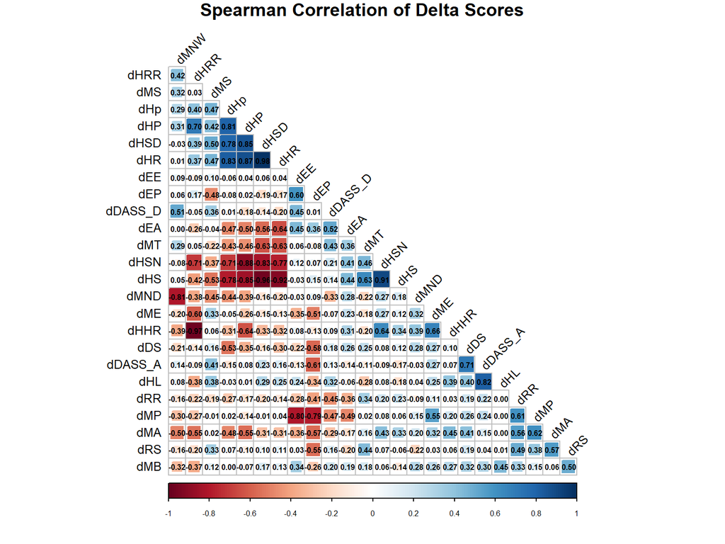

**Detailed Spearman Correlation Matrix:**

| Variable1 | Variable2 | Spearman_rho | CI_Lower | CI_Upper | p_adjusted_holm |
| --- | --- | --- | --- | --- | --- |
| dDASS_D | dDASS_A | 0.129 | -0.525 | 0.688 | 1.000 |
| dDASS_D | dDS | 0.177 | -0.489 | 0.713 | 1.000 |
| dDASS_D | dRR | -0.455 | -0.835 | 0.219 | 1.000 |
| dDASS_D | dRS | 0.159 | -0.503 | 0.703 | 1.000 |
| dDASS_D | dMP | -0.465 | -0.839 | 0.207 | 1.000 |
| dDASS_D | dMND | -0.334 | -0.786 | 0.350 | 1.000 |
| dDASS_D | dMNW | 0.511 | -0.149 | 0.856 | 1.000 |
| dDASS_D | dMA | -0.290 | -0.766 | 0.393 | 1.000 |
| dDASS_D | dME | -0.074 | -0.657 | 0.565 | 1.000 |
| dDASS_D | dMS | 0.359 | -0.325 | 0.797 | 1.000 |
| dDASS_D | dMB | 0.205 | -0.467 | 0.726 | 1.000 |
| dDASS_D | dMT | 0.433 | -0.245 | 0.827 | 1.000 |
| dDASS_D | dEE | 0.452 | -0.222 | 0.834 | 1.000 |
| dDASS_D | dEP | 0.009 | -0.607 | 0.619 | 1.000 |
| dDASS_D | dEA | 0.517 | -0.140 | 0.858 | 1.000 |
| dDASS_D | dHP | -0.184 | -0.716 | 0.483 | 1.000 |
| dDASS_D | dHSN | 0.207 | -0.465 | 0.727 | 1.000 |
| dDASS_D | dHS | 0.143 | -0.515 | 0.695 | 1.000 |
| dDASS_D | dHRR | -0.046 | -0.641 | 0.583 | 1.000 |
| dDASS_D | dHSD | -0.143 | -0.695 | 0.515 | 1.000 |
| dDASS_D | dHHR | 0.087 | -0.555 | 0.665 | 1.000 |
| dDASS_D | dHR | -0.202 | -0.725 | 0.469 | 1.000 |
| dDASS_D | dHp | 0.014 | -0.604 | 0.621 | 1.000 |
| dDASS_D | dHL | 0.317 | -0.367 | 0.779 | 1.000 |
| dDASS_A | dDS | 0.713 | 0.178 | 0.923 | 1.000 |
| dDASS_A | dRR | 0.225 | -0.450 | 0.736 | 1.000 |
| dDASS_A | dRS | 0.044 | -0.585 | 0.639 | 1.000 |
| dDASS_A | dMP | 0.240 | -0.437 | 0.744 | 1.000 |
| dDASS_A | dMND | -0.027 | -0.630 | 0.595 | 1.000 |
| dDASS_A | dMNW | 0.140 | -0.517 | 0.693 | 1.000 |

[output cut: 270 more lines]

# 5 **Exploratory Analysis of Predictors of Significant Changes in the Experimental Group (N=11)**

After identifying outcome variables that showed significant improvement or a trend towards improvement in the experimental group as a result of the intervention (specifically, Depression, Stress, MAIA Self-Regulation, and MAIA Attentional Regulation, based on GEE and post-hoc analyses), this section explores which other changes (T2-T1 deltas) might predict these improvements.

## 5.1 **Predictors of Depression**

Regarding depression, a central finding was that an increase in the change in cognitive reappraisal from T1 to T2 was significantly associated with a greater reduction in depression symptoms (a more negative T2-T1 delta for depression), when controlling for the change in interoceptive trust (coefficient for Delta RegEmoc_ReavCog = -1.20, p = 0.019). This result suggests that enhancing the ability to cognitively reappraise situations may be an important therapeutic mechanism in reducing depressive symptomatology in this group.

Interestingly, the relationship between the change in interoceptive trust (dMT) and depression proved more complex. When analyzed in isolation, the change in ‘Trusting’ did not show a significant association with the change in depression scores (p = 0.368). Similarly, the change in ‘Cognitive Reappraisal’, when analyzed in isolation, did not show a significant association (p = 0.1367). However, in the multiple regression model, a greater increase in interoceptive trust (Delta MAIA_Trusting) was associated with a less negative or even positive delta for depression (indicating less reduction or a slight increase in symptoms), after controlling for the change in cognitive reappraisal (coefficient dMT = 5.99, p = 0.040).

This finding for ‘Trusting’ is counterintuitive and must be interpreted with extreme caution due to the small sample size. It might indicate that the “benefit” (or the nature of the change) of an increase in trust in one’s own bodily sensations (dMT) could depend on the simultaneous development of other skills, such as cognitive reappraisal (dRR). **If the ability to cognitively reappraise does not accompany an increase in confidence in sensations, it is possible that an increased focus on these sensations, without tools to process them adaptively, may not be beneficial for depressive symptoms, and could even be problematic (for example, leading to a greater focus on negative sensations)**. More complex relationships or the influence of other unmeasured variables may be at play and warrant future investigation.

The final model with Trusting and Cognitive Reappraisal explained approximately 45% of the variance in the change in depression scores (Adjusted R² = 0.45, F(2, 8) = 5.09, p = 0.037). Although this is a considerable proportion of the variance, the exploratory nature of this analysis, given the small sample size, requires these findings to be viewed as hypothesis-generating for future studies with greater statistical power. The model residuals met the assumptions of normality, homoscedasticity, and absence of autocorrelation.

```r
dass_d <- lm(dDASS_D ~ dMT + dRR
  #+ dMS + dEE + dEP + dMP + dMA
  , data = df_deltas_g1_final)

summary(dass_d)
```

```
##
## Call:
## lm(formula = dDASS_D ~ dMT + dRR, data = df_deltas_g1_final)
##
## Residuals:
##    Min     1Q Median     3Q    Max
## -8.145 -3.498  1.476  3.488  9.084
##
## Coefficients:
##             Estimate Std. Error t value Pr(>|t|)
## (Intercept) -15.4819     2.6523  -5.837 0.000388 ***
## dMT           5.9879     2.4403   2.454 0.039705 *
## dRR          -1.2029     0.4118  -2.921 0.019265 *
## ---
## Signif. codes:  0 '***' 0.001 '**' 0.01 '*' 0.05 '.' 0.1 ' ' 1
##
## Residual standard error: 5.937 on 8 degrees of freedom
## Multiple R-squared:   0.56,  Adjusted R-squared:   0.45
## F-statistic:  5.09 on 2 and 8 DF,  p-value: 0.03749
```

```r
ols_step_backward_aic(dass_d)
```

```
## [1] "No variables have been removed from the model."
```

```r
ols_step_backward_p(dass_d)
```

```
## [1] "No variables have been removed from the model."
```

```r
betas_d <- lm.beta(dass_d)$standardized.coefficients
betas_d
```

```
## (Intercept)         dMT         dRR
##          NA   0.6432474  -0.7657119
```

```r
#Residuals normality
shapiro.test(resid(dass_d)) #p > 0,05
```

```
##
##  Shapiro-Wilk normality test
##
## data:  resid(dass_d)
## W = 0.95112, p-value = 0.6583
```

```r
#Homoscedasticity
ols_test_breusch_pagan(dass_d) #p > 0,05
```

```
##
##  Breusch Pagan Test for Heteroskedasticity
##  -----------------------------------------
##  Ho: the variance is constant
##  Ha: the variance is not constant
##
##                Data
##  -----------------------------------
##  Response : dDASS_D
##  Variables: fitted values of dDASS_D
##
##         Test Summary
##  ----------------------------
##  DF            =    1
##  Chi2          =    0.3266264
##  Prob > Chi2   =    0.5676524
```

```r
#Residual autocorrelations
durbinWatsonTest(dass_d)   # p > 0,05
```

```
##  lag Autocorrelation D-W Statistic p-value
##    1      -0.1874844      2.074553   0.774
##  Alternative hypothesis: rho != 0
```

```r
dass_d_cnf <- lm(dDASS_D ~ dMT, data = df_deltas_g1_final)
summary(dass_d_cnf)
```

```
##
## Call:
## lm(formula = dDASS_D ~ dMT, data = df_deltas_g1_final)
##
## Residuals:
##     Min      1Q  Median      3Q     Max
## -17.246  -3.180   1.147   4.885  10.885
##
## Coefficients:
##             Estimate Std. Error t value Pr(>|t|)
## (Intercept)  -12.754      3.365  -3.791  0.00428 **
## dMT            2.803      2.959   0.947  0.36818
## ---
## Signif. codes:  0 '***' 0.001 '**' 0.01 '*' 0.05 '.' 0.1 ' ' 1
##
## Residual standard error: 8.046 on 9 degrees of freedom
## Multiple R-squared:  0.09068,    Adjusted R-squared:  -0.01035
## F-statistic: 0.8976 on 1 and 9 DF,  p-value: 0.3682
```

```r
dass_d_rc <- lm(dDASS_D ~ dRR, data = df_deltas_g1_final)
summary(dass_d_rc)
```

```
##
## Call:
## lm(formula = dDASS_D ~ dRR, data = df_deltas_g1_final)
##
## Residuals:
##      Min       1Q   Median       3Q      Max
## -14.8095   0.0522   1.9419   3.1849   9.1793
##
## Coefficients:
##             Estimate Std. Error t value Pr(>|t|)
## (Intercept) -10.6821     2.2357  -4.778    0.001 **
## dRR          -0.7514     0.4599  -1.634    0.137
## ---
## Signif. codes:  0 '***' 0.001 '**' 0.01 '*' 0.05 '.' 0.1 ' ' 1
##
## Residual standard error: 7.41 on 9 degrees of freedom
## Multiple R-squared:  0.2288, Adjusted R-squared:  0.1431
## F-statistic:  2.67 on 1 and 9 DF,  p-value: 0.1367
```

## 5.2 **Predictors of Stress**

When examining the linear model with Stress (Delta DASS_Str) as the dependent variable, initially, neither the change in the percentage of adjacent NN intervals differing by more than 50 ms (dHp) (p = 0.130) nor the change in the use of problem-focused coping musical listening (dEP) (p = 0.077) were statistically significant predictors of the change in stress when analyzed in isolation.

However, the final selected model, including both variables, was significant (F(2, 8) = 6.241, p = 0.023) and explained approximately 51% of the variance in the change in stress scores (Adjusted R² = 0.5118). In this model, both dHp and dEP emerged as significant predictors.

Specifically, a greater increase in dHp (indicating an increase in high-frequency heart rate variability, often associated with parasympathetic activity) predicted a greater reduction in stress symptoms (standardized beta coefficient ≈ -0.55, p = 0.038). Additionally, a greater increase in the use of problem-focused coping strategies by listening to music (dEP) also predicted a greater reduction in stress (standardized beta coefficient ≈ -0.61, p = 0.025). The model residuals met the assumptions of normality, homoscedasticity, and absence of autocorrelation.

These exploratory findings, though based on a small sample (N=11), suggest that the music therapy intervention may have influenced stress reduction in the experimental group through mechanisms involving both physiological changes (improvement in parasympathetic modulation) and changes in coping strategies through problem-focused music listening. The fact that these variables gained significance when considered together may indicate that their effects are better understood in each other’s presence, possibly due to mutual suppression effects or because they capture complementary facets of the response to the intervention. The relationship between the increase in problem-focused coping and stress reduction, in particular, is interesting and warrants future investigation, especially considering the context of a primarily experiential intervention.

```r
dass_s <- lm(dDS ~ dHp + dEP
             # + dDASS_A + dHL + dMA
             , data = df_deltas_g1_final)
summary(dass_s)
```

```
##
## Call:
## lm(formula = dDS ~ dHp + dEP, data = df_deltas_g1_final)
##
## Residuals:
##     Min      1Q  Median      3Q     Max
## -7.6676 -2.3271 -0.9514  3.3444  9.4046
##
## Coefficients:
##             Estimate Std. Error t value Pr(>|t|)
## (Intercept)  -2.1059     2.2261  -0.946   0.3718
## dHp          -0.4785     0.1925  -2.486   0.0377 *
## dEP          -2.1132     0.7642  -2.765   0.0245 *
## ---
## Signif. codes:  0 '***' 0.001 '**' 0.01 '*' 0.05 '.' 0.1 ' ' 1
##
## Residual standard error: 5.722 on 8 degrees of freedom
## Multiple R-squared:  0.6094, Adjusted R-squared:  0.5118
## F-statistic: 6.241 on 2 and 8 DF,  p-value: 0.02327
```

```r
ols_step_backward_aic(dass_s)
```

```
## [1] "No variables have been removed from the model."
```

```r
ols_step_backward_p(dass_s)
```

```
## [1] "No variables have been removed from the model."
```

```r
betas_s <- lm.beta(dass_s)$standardized.coefficients
betas_s
```

```
## (Intercept)         dHp         dEP
##          NA  -0.5525873  -0.6146550
```

```r
#Normality of residuals
shapiro.test(resid(dass_s))
```

```
##
##  Shapiro-Wilk normality test
##
## data:  resid(dass_s)
## W = 0.96955, p-value = 0.882
```

```r
#Homoscedasticity (Breusch-Pagan test)
ols_test_breusch_pagan(dass_s)
```

```
##
##  Breusch Pagan Test for Heteroskedasticity
##  -----------------------------------------
##  Ho: the variance is constant
##  Ha: the variance is not constant
##
##              Data
##  -------------------------------
##  Response : dDS
##  Variables: fitted values of dDS
##
##          Test Summary
##  -------------------------------
##  DF            =    1
##  Chi2          =    2.777505e-06
##  Prob > Chi2   =    0.9986703
```

```r
#Autocorrelation of residuals (Durbin-Watson test)
durbinWatsonTest(dass_s)
```

```
##  lag Autocorrelation D-W Statistic p-value
##    1      0.02748428      1.839682   0.966
##  Alternative hypothesis: rho != 0
```

```r
dass_e_pNN <- lm(dDS ~ dHp, data = df_deltas_g1_final)
summary(dass_e_pNN)
```

```
##
## Call:
## lm(formula = dDS ~ dHp, data = df_deltas_g1_final)
##
## Residuals:
##     Min      1Q  Median      3Q     Max
## -10.536  -5.131   0.052   4.409  11.982
##
## Coefficients:
##             Estimate Std. Error t value Pr(>|t|)
## (Intercept)  -3.4645     2.8629  -1.210    0.257
## dHp          -0.4207     0.2523  -1.668    0.130
##
## Residual standard error: 7.544 on 9 degrees of freedom
## Multiple R-squared:  0.2361, Adjusted R-squared:  0.1512
## F-statistic: 2.781 on 1 and 9 DF,  p-value: 0.1297
```

```r
dass_e_ECOM_P <- lm(dDS ~ dEP, data = df_deltas_g1_final)
summary(dass_e_ECOM_P)
```

```
##
## Call:
## lm(formula = dDS ~ dEP, data = df_deltas_g1_final)
##
## Residuals:
##      Min       1Q   Median       3Q      Max
## -14.2244  -3.7356  -0.2244   4.4503  11.4968
##
## Coefficients:
##             Estimate Std. Error t value Pr(>|t|)
## (Intercept)  -5.4968     2.2084  -2.489   0.0345 *
## dEP          -1.9071     0.9536  -2.000   0.0766 .
## ---
## Signif. codes:  0 '***' 0.001 '**' 0.01 '*' 0.05 '.' 0.1 ' ' 1
##
## Residual standard error: 7.182 on 9 degrees of freedom
## Multiple R-squared:  0.3077, Adjusted R-squared:  0.2307
## F-statistic:     4 on 1 and 9 DF,  p-value: 0.07656
```

## 5.3 **Predictors of Self-Regulation**

In the experimental group , exploratory linear regression analysis, following backward selection, indicated that changes (T2-T1 delta) in the HRV Stress Index (dHM) and in the ‘Not Distracting’ subscale of the MAIA (dMND) were significant predictors of the change in Interoceptive Self-Regulation (dMS).

The final model was statistically significant (F(2, 8) = 8.347, p = 0.011) and explained approximately 59.5% of the variance in the change in interoceptive self-regulation (Adjusted R² = 0.5951). The model residuals met the assumptions of normality, homoscedasticity, and absence of autocorrelation.

Specifically, a greater increase in the HRV Stress Index (dHS) predicted less improvement (or a worsening) in interoceptive self-regulation (standardized beta coefficient ≈ -0.59, p = 0.019). This finding suggests that an increase in physiological stress may hinder the ability for self-regulation based on bodily sensations.

Interestingly, a greater increase in the ability to ‘Not be Distracted’ by bodily sensations (dMND) also predicted less improvement (or a worsening) in interoceptive self-regulation (standardized beta coefficient ≈ -0.56, p = 0.025), after controlling for the change in physiological stress. This result might indicate that an increased attention to sensations, without parallel development of other facets of interoception (such as adaptive interpretation or the capacity for emotional regulation based on these sensations, which are more central to ‘Self-Regulation’), may not directly translate into better perceived self-regulation, and warrants further investigation.

These findings, though based on a small sample, raise hypotheses about the interrelated mechanisms of physiological and interoceptive change following the music therapy intervention.

```r
maia_ar <- lm(dMS ~ dHS + dMND
              # + dHp + dHP + dEP + dHSD + dHR + dDASS_A
              , data = df_deltas_g1_final)
summary(maia_ar)
```

```
##
## Call:
## lm(formula = dMS ~ dHS + dMND, data = df_deltas_g1_final)
##
## Residuals:
##      Min       1Q   Median       3Q      Max
## -0.60143 -0.27414 -0.07203  0.25003  0.61619
##
## Coefficients:
##             Estimate Std. Error t value Pr(>|t|)
## (Intercept)  0.89343    0.13781   6.483 0.000191 ***
## dHS         -0.06510    0.02221  -2.931 0.018957 *
## dMND        -0.38210    0.13857  -2.757 0.024771 *
## ---
## Signif. codes:  0 '***' 0.001 '**' 0.01 '*' 0.05 '.' 0.1 ' ' 1
##
## Residual standard error: 0.4433 on 8 degrees of freedom
## Multiple R-squared:  0.676,  Adjusted R-squared:  0.5951
## F-statistic: 8.347 on 2 and 8 DF,  p-value: 0.01101
```

```r
ols_step_backward_aic(maia_ar)
```

```
## [1] "No variables have been removed from the model."
```

```r
ols_step_backward_p(maia_ar)
```

```
## [1] "No variables have been removed from the model."
```

```r
betas_AR <- lm.beta(maia_ar)$standardized.coefficients
betas_AR
```

```
## (Intercept)         dHS        dMND
##          NA  -0.5901604  -0.5551454
```

```r
shapiro.test(resid(maia_ar))
```

```
##
##  Shapiro-Wilk normality test
##
## data:  resid(maia_ar)
## W = 0.89876, p-value = 0.1785
```

```r
ols_test_breusch_pagan(maia_ar)
```

```
##
##  Breusch Pagan Test for Heteroskedasticity
##  -----------------------------------------
##  Ho: the variance is constant
##  Ha: the variance is not constant
##
##              Data
##  -------------------------------
##  Response : dMS
##  Variables: fitted values of dMS
##
##         Test Summary
##  ----------------------------
##  DF            =    1
##  Chi2          =    1.900975
##  Prob > Chi2   =    0.1679692
```

```r
durbinWatsonTest(maia_ar)
```

```
##  lag Autocorrelation D-W Statistic p-value
##    1     -0.03073948      1.872514   0.832
##  Alternative hypothesis: rho != 0
```

```r
maia_ar_dHS <- lm(dMS ~ dHS, data = df_deltas_g1_final)
summary(maia_ar_dHS)
```

```
##
## Call:
## lm(formula = dMS ~ dHS, data = df_deltas_g1_final)
##
## Residuals:
##     Min      1Q  Median      3Q     Max
## -0.9564 -0.3804  0.1047  0.3921  0.7334
##
## Coefficients:
##             Estimate Std. Error t value Pr(>|t|)
## (Intercept)  0.80095    0.17600   4.551  0.00138 **
## dHS         -0.06693    0.02923  -2.290  0.04779 *
## ---
## Signif. codes:  0 '***' 0.001 '**' 0.01 '*' 0.05 '.' 0.1 ' ' 1
##
## Residual standard error: 0.5837 on 9 degrees of freedom
## Multiple R-squared:  0.3681, Adjusted R-squared:  0.2979
## F-statistic: 5.243 on 1 and 9 DF,  p-value: 0.04779
```

```r
maia_ar_MND <- lm(dMS ~ dMND, data = df_deltas_g1_final)
summary(maia_ar_MND)
```

```
##
## Call:
## lm(formula = dMS ~ dMND, data = df_deltas_g1_final)
##
## Residuals:
##     Min      1Q  Median      3Q     Max
## -1.1410 -0.2660 -0.1538  0.4311  0.8590
##
## Coefficients:
##             Estimate Std. Error t value Pr(>|t|)
## (Intercept)   0.8910     0.1871   4.762  0.00103 **
## dMND         -0.3942     0.1881  -2.096  0.06552 .
## ---
## Signif. codes:  0 '***' 0.001 '**' 0.01 '*' 0.05 '.' 0.1 ' ' 1
##
## Residual standard error: 0.6019 on 9 degrees of freedom
## Multiple R-squared:  0.3281, Adjusted R-squared:  0.2534
## F-statistic: 4.394 on 1 and 9 DF,  p-value: 0.06552
```

## 5.4 **Predictors of Attentional Regulation**

An improvement in the ability to Perceive bodily sensations (dMP) was a strong positive predictor of improvement in Attentional Regulation (standardized beta coefficient ≈ 0.80, p < 0.001), suggesting that as participants became more aware of their sensations, their ability to regulate attention towards them also increased.

Interestingly, a greater increase in the Parasympathetic Index (dHP) was associated with less improvement (or a slight worsening) in Attentional Regulation (standardized beta coefficient ≈ -0.51, p = 0.010), when controlling for the change in perception. In isolation, the change in the PNS Index was not a significant predictor of change in MAIA Attentional Regulation capacity (p = 0.183). This finding in the multiple model is counterintuitive, as an increase in parasympathetic activity is generally seen as beneficial. **It could indicate that an excessive increase in physiological relaxation, in the context of other interoceptive changes, might paradoxically make it harder to actively direct attention, or that the relationship is more complex and mediated by other unincluded factors**.

These exploratory results, considering the small sample, point towards an intriguing interplay between physiological changes and different facets of interoception. The enhanced ability to perceive sensations seems fundamental for improving attentional regulation, while the role of changes in parasympathetic tone in this specific process of attentional regulation appears more complex than a simple linear positive relationship.

```r
maia_ra <- lm(dMA ~  dHP + dMP
              #+ dEP + dRS + dMND + dHRR
              , data = df_deltas_g1_final)

summary(maia_ra)
```

```
##
## Call:
## lm(formula = dMA ~ dHP + dMP, data = df_deltas_g1_final)
##
## Residuals:
##      Min       1Q   Median       3Q      Max
## -0.64311 -0.17789 -0.03771  0.24913  0.50546
##
## Coefficients:
##             Estimate Std. Error t value Pr(>|t|)
## (Intercept)  0.74433    0.12928   5.758 0.000425 ***
## dHP         -0.61598    0.18255  -3.374 0.009724 **
## dMP          0.50274    0.09468   5.310 0.000720 ***
## ---
## Signif. codes:  0 '***' 0.001 '**' 0.01 '*' 0.05 '.' 0.1 ' ' 1
##
## Residual standard error: 0.379 on 8 degrees of freedom
## Multiple R-squared:  0.8204, Adjusted R-squared:  0.7755
## F-statistic: 18.27 on 2 and 8 DF,  p-value: 0.00104
```

```r
ols_step_backward_aic(maia_ra)
```

```
## [1] "No variables have been removed from the model."
```

```r
ols_step_backward_p(maia_ra)
```

```
## [1] "No variables have been removed from the model."
```

```r
betas_AR <- lm.beta(maia_ra)$standardized.coefficients
betas_AR
```

```
## (Intercept)         dHP         dMP
##          NA  -0.5077775   0.7990820
```

```r
#Residuals normality
shapiro.test(resid(maia_ar)) #p > 0,05
```

```
##
##  Shapiro-Wilk normality test
##
## data:  resid(maia_ar)
## W = 0.89876, p-value = 0.1785
```

```r
#Homoscedasticity
ols_test_breusch_pagan(maia_ar) #p > 0,05
```

```
##
##  Breusch Pagan Test for Heteroskedasticity
##  -----------------------------------------
##  Ho: the variance is constant
##  Ha: the variance is not constant
##
##              Data
##  -------------------------------
##  Response : dMS
##  Variables: fitted values of dMS
##
##         Test Summary
##  ----------------------------
##  DF            =    1
##  Chi2          =    1.900975
##  Prob > Chi2   =    0.1679692
```

```r
#Residual autocorrelations
durbinWatsonTest(maia_ar)
```

```
##  lag Autocorrelation D-W Statistic p-value
##    1     -0.03073948      1.872514   0.882
##  Alternative hypothesis: rho != 0
```

```r
MA_HP <- lm(dMA ~  dHP, data = df_deltas_g1_final)
summary(MA_HP)
```

```
##
## Call:
## lm(formula = dMA ~ dHP, data = df_deltas_g1_final)
##
## Residuals:
##      Min       1Q   Median       3Q      Max
## -1.13286 -0.24638 -0.05292  0.23720  1.29701
##
## Coefficients:
##             Estimate Std. Error t value Pr(>|t|)
## (Intercept)   0.7714     0.2591   2.978   0.0155 *
## dHP          -0.5253     0.3645  -1.441   0.1834
## ---
## Signif. codes:  0 '***' 0.001 '**' 0.01 '*' 0.05 '.' 0.1 ' ' 1
##
## Residual standard error: 0.7602 on 9 degrees of freedom
## Multiple R-squared:  0.1875, Adjusted R-squared:  0.0972
## F-statistic: 2.077 on 1 and 9 DF,  p-value: 0.1834
```

```r
MA_MP <- lm(dMA ~  dMP, data = df_deltas_g1_final)
summary(MA_MP)
```

```
##
## Call:
## lm(formula = dMA ~ dMP, data = df_deltas_g1_final)
##
## Residuals:
##      Min       1Q   Median       3Q      Max
## -1.04618 -0.22601  0.00311  0.31598  0.97847
##
## Coefficients:
##             Estimate Std. Error t value Pr(>|t|)
## (Intercept)   0.5437     0.1685   3.227  0.01037 *
## dMP           0.4728     0.1383   3.418  0.00765 **
## ---
## Signif. codes:  0 '***' 0.001 '**' 0.01 '*' 0.05 '.' 0.1 ' ' 1
##
## Residual standard error: 0.5563 on 9 degrees of freedom
## Multiple R-squared:  0.5648, Adjusted R-squared:  0.5165
## F-statistic: 11.68 on 1 and 9 DF,  p-value: 0.007653
```